# Working with regressions using dplyr

Author

Student

Published

January 22, 2025

# Regression and `dplyr`

## Running regressions

The non-`tidyverse` method of doing a regression (aka the base R way) is the example seen online in the following code:

```
reg=lm(Y~X1+X2+X3,data=dat)
summary(reg)
```

In this example, `Y` is the response variable and the `Xn` variables are the predictor variables.

The `summary()` command then provides the regression results, but it can be hard to work with to print or manipulate your results.

In `dplyr`, there are ways to more helpfully produce your regression results. For this, we will need the `broom` library. You first need to create your regression the standard way as above.

We can then tidy the results with the following command from the `broom` library:

[output not shown]

This returns the regression results as a data frame.

We can also view some of the regression diagnostics (don’t worry about any of the terms yet besides the $r^2$)

[output not shown]

> Create a regression using the `mtcars` dataset and a different predictor variable. Tidy the results and produce the model fit statistics, then interpret your results.
1. Based on simply the results, how good of a fit do you think your model is?
2. For a one unit change in $x$, how much change is there in $y$? Do you estimate that to be a lot or a little?
3. How can you interpret the intercept? Is the intercept meaningful?

## Getting the residuals

To get the residuals from a dataset, we need to use the `augment()` command from the `broom` library.

[output not shown]

Notice that when you inspect this new, augmented dataset, it has a number of new data columns. The ones we are most interested in is the `.fitted` and the `.resid`.

We can use the `.resid` column to make a histogram of the residuals.

> Make a histogram of your residuals
1. What are we hoping to see in a histogram of the residuals?
2. What do you observe in your residual histogram? Are there any problems?

We can also make a plot of the residuals vs. fitted values. This tells that for any given predicted value of $y$ ($\hat{y}$) how much we ‘missed’ the prediction by. If there are systematic patterns in this graph, that indicates some possible non-linearity, outlier, or plot thickens condition in the relationship between your predictor variable(s) and response variable.

> Make a scatterplot of your residuals vs. predicted (predicted on $x$ axis). Draw a horizontal line at the $0$ value for the $y$ axis.
1. How does your plot look? Do you estimate that there are any problems?
2. Interpret your overall model fit based on the residual plots

## Nicely printing your regression results

You can use plain old `kable()` to make your regression table from the results of the `tidy()` command but we can do better than this simple table. There are many libraries that print out pretty version of a standard regression table. I particularly like the one called `modelsummary()` (details can be found [here](https://vincentarelbundock.github.io/modelsummary/articles/modelsummary.html)).

You can simply use it as follows:

[output not shown]

You can add several models to one table as follows:

[output not shown]

> Create a nice table of your results. Rename the predictor variable in the table to something human readable (see the `coef_rename` section)

# Going deeper

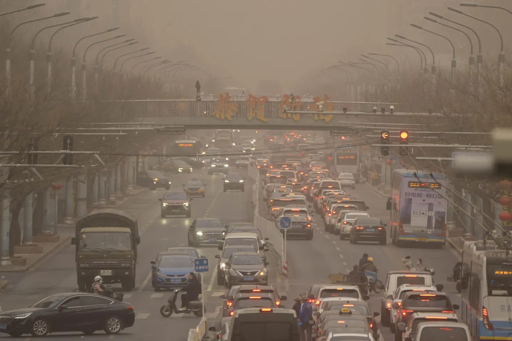

Bar air day

Using the provided `china-aqi.csv` file,

1. Choose a predictor variable and a response variable
2. Make a scatterplot of the relationship and add a smoother - do you feel the relationship is a good fit?
3. Generate the regression results. Interpret your regression coefficients.
4. Check the residuals - do they confirm your visual inspection from the scatterplot? Why or why not?
5. Create a high-quality table based on your regression results using the `modelsummary()` command

If you have time, do the same for another predictor variable and the same response variable and add the results to your `modelsummary()` table.